# Data Science Final Project:

## Data Reading, Cleaning, and Information

### Import libraries

```python
import numpy as np
import pandas as pd
import matplotlib.pyplot as plt
```

### Read data and name the dataframe

```python
df = pd.read_csv('../ds_salaries.csv')
```

### Quick look at the data

```python
df.head(5)
```

|  | work_year | experience_level | employment_type | job_title | salary | salary_currency | salary_in_usd | employee_residence | remote_ratio | company_location | company_size |
| --- | --- | --- | --- | --- | --- | --- | --- | --- | --- | --- | --- |
| 0 | 2023 | SE | FT | Principal Data Scientist | 80000 | EUR | 85847 | ES | 100 | ES | L |
| 1 | 2023 | MI | CT | ML Engineer | 30000 | USD | 30000 | US | 100 | US | S |
| 2 | 2023 | MI | CT | ML Engineer | 25500 | USD | 25500 | US | 100 | US | S |
| 3 | 2023 | SE | FT | Data Scientist | 175000 | USD | 175000 | CA | 100 | CA | M |
| 4 | 2023 | SE | FT | Data Scientist | 120000 | USD | 120000 | CA | 100 | CA | M |

### Display basic information on dataframe

```python
df.info()
```

```
<class 'pandas.core.frame.DataFrame'>
RangeIndex: 3755 entries, 0 to 3754
Data columns (total 11 columns):
 #   Column              Non-Null Count  Dtype
---  ------              --------------  -----
 0   work_year           3755 non-null   int64
 1   experience_level    3755 non-null   object
 2   employment_type     3755 non-null   object
 3   job_title           3755 non-null   object
 4   salary              3755 non-null   int64
 5   salary_currency     3755 non-null   object
 6   salary_in_usd       3755 non-null   int64
 7   employee_residence  3755 non-null   object
 8   remote_ratio        3755 non-null   int64
 9   company_location    3755 non-null   object
 10  company_size        3755 non-null   object
dtypes: int64(4), object(7)
memory usage: 322.8+ KB
```

### Display discriptive statistics

#### Shows standard deviation, mean, count, minumum, maximum, and quartiles.

```python
df.describe()
```

|  | work_year | salary | salary_in_usd | remote_ratio |
| --- | --- | --- | --- | --- |
| count | 3755.000000 | 3.755000e+03 | 3755.000000 | 3755.000000 |
| mean | 2022.373635 | 1.906956e+05 | 137570.389880 | 46.271638 |
| std | 0.691448 | 6.716765e+05 | 63055.625278 | 48.589050 |
| min | 2020.000000 | 6.000000e+03 | 5132.000000 | 0.000000 |
| 25% | 2022.000000 | 1.000000e+05 | 95000.000000 | 0.000000 |
| 50% | 2022.000000 | 1.380000e+05 | 135000.000000 | 0.000000 |
| 75% | 2023.000000 | 1.800000e+05 | 175000.000000 | 100.000000 |
| max | 2023.000000 | 3.040000e+07 | 450000.000000 | 100.000000 |

### Check to see if there are nulls

```python
df.isnull().sum()
```

```
work_year             0
experience_level      0
employment_type       0
job_title             0
salary                0
salary_currency       0
salary_in_usd         0
employee_residence    0
remote_ratio          0
company_location      0
company_size          0
dtype: int64
```

### Check for any duplicates

```python
df[df.duplicated()]
```

|  | work_year | experience_level | employment_type | job_title | salary | salary_currency | salary_in_usd | employee_residence | remote_ratio | company_location | company_size |
| --- | --- | --- | --- | --- | --- | --- | --- | --- | --- | --- | --- |
| 115 | 2023 | SE | FT | Data Scientist | 150000 | USD | 150000 | US | 0 | US | M |
| 123 | 2023 | SE | FT | Analytics Engineer | 289800 | USD | 289800 | US | 0 | US | M |
| 153 | 2023 | MI | FT | Data Engineer | 100000 | USD | 100000 | US | 100 | US | M |
| 154 | 2023 | MI | FT | Data Engineer | 70000 | USD | 70000 | US | 100 | US | M |
| 160 | 2023 | SE | FT | Data Engineer | 115000 | USD | 115000 | US | 0 | US | M |
| ... | ... | ... | ... | ... | ... | ... | ... | ... | ... | ... | ... |
| 3439 | 2022 | MI | FT | Data Scientist | 78000 | USD | 78000 | US | 100 | US | M |
| 3440 | 2022 | SE | FT | Data Engineer | 135000 | USD | 135000 | US | 100 | US | M |
| 3441 | 2022 | SE | FT | Data Engineer | 115000 | USD | 115000 | US | 100 | US | M |
| 3586 | 2021 | MI | FT | Data Engineer | 200000 | USD | 200000 | US | 100 | US | L |
| 3709 | 2021 | MI | FT | Data Scientist | 76760 | EUR | 90734 | DE | 50 | DE | L |

1171 rows × 11 columns

#### We find there are 1171 duplicated rows in the dataset, however we will keep the duplicates because different people can have the same information in this scenario. In short, it makes sense for there to be some duplicates in this dataset...this is good.

#### Now that we have a clean dataset to work with, we can start analyzing.

## Q1) Find the average sallary for each job title in US dollars.

#### Someone looking for jobs in the "data" field may want to know what the average salary is for the different job titles.

#### First take a look at the job titles.

```python
df[['job_title']]
```

|  | job_title |
| --- | --- |
| 0 | Principal Data Scientist |
| 1 | ML Engineer |
| 2 | ML Engineer |
| 3 | Data Scientist |
| 4 | Data Scientist |
| ... | ... |
| 3750 | Data Scientist |
| 3751 | Principal Data Scientist |
| 3752 | Data Scientist |
| 3753 | Business Data Analyst |
| 3754 | Data Science Manager |

3755 rows × 1 columns

#### Now we check to see how many unique job titles there are.

```python
df['job_title'].nunique()
```

```
93
```

#### Create your new dataframe of unique job titles and their average salary in US dollars. We need to get the mean of the salaries in US dollars by grouping by the job titles.

```python
jobsal=pd.DataFrame(df.groupby('job_title')['salary_in_usd'].mean())
jobsal
```

| job_title | salary_in_usd |
| --- | --- |
| 3D Computer Vision Researcher | 21352.250000 |
| AI Developer | 136666.090909 |
| AI Programmer | 55000.000000 |
| AI Scientist | 110120.875000 |
| Analytics Engineer | 152368.631068 |
| ... | ... |
| Research Engineer | 163108.378378 |
| Research Scientist | 161214.195122 |
| Software Data Engineer | 62510.000000 |
| Staff Data Analyst | 15000.000000 |
| Staff Data Scientist | 105000.000000 |

93 rows × 1 columns

#### Note that our new dataframe is not structured properly yet, we need job_title as a column, rather than the index. We have to create a new column based on the index values.

```python
jobsal['job_title']=jobsal.index
```

#### Now we need to create another column that will become our new index.

```python
jobsal['index']=range(1,jobsal.shape[0]+1)
```

#### Set our new index column as the index.

```python
jobsal=jobsal.set_index('index')
```

#### Check to see that our dataframe has the proper index and columns.

```python
jobsal
```

| index | salary_in_usd | job_title |
| --- | --- | --- |
| 1 | 21352.250000 | 3D Computer Vision Researcher |
| 2 | 136666.090909 | AI Developer |
| 3 | 55000.000000 | AI Programmer |
| 4 | 110120.875000 | AI Scientist |
| 5 | 152368.631068 | Analytics Engineer |
| ... | ... | ... |
| 89 | 163108.378378 | Research Engineer |
| 90 | 161214.195122 | Research Scientist |
| 91 | 62510.000000 | Software Data Engineer |
| 92 | 15000.000000 | Staff Data Analyst |
| 93 | 105000.000000 | Staff Data Scientist |

93 rows × 2 columns

#### We can reorder the columns into a more intuitive order.

```python
jobsal=jobsal[['job_title','salary_in_usd']]
jobsal
```

| index | job_title | salary_in_usd |
| --- | --- | --- |
| 1 | 3D Computer Vision Researcher | 21352.250000 |
| 2 | AI Developer | 136666.090909 |
| 3 | AI Programmer | 55000.000000 |
| 4 | AI Scientist | 110120.875000 |
| 5 | Analytics Engineer | 152368.631068 |
| ... | ... | ... |
| 89 | Research Engineer | 163108.378378 |
| 90 | Research Scientist | 161214.195122 |
| 91 | Software Data Engineer | 62510.000000 |
| 92 | Staff Data Analyst | 15000.000000 |
| 93 | Staff Data Scientist | 105000.000000 |

93 rows × 2 columns

#### We can produce a visual representation of our new dataframe via barchart. Put the unique job titles we found on the x axis, and the average salaries on the y-axis.

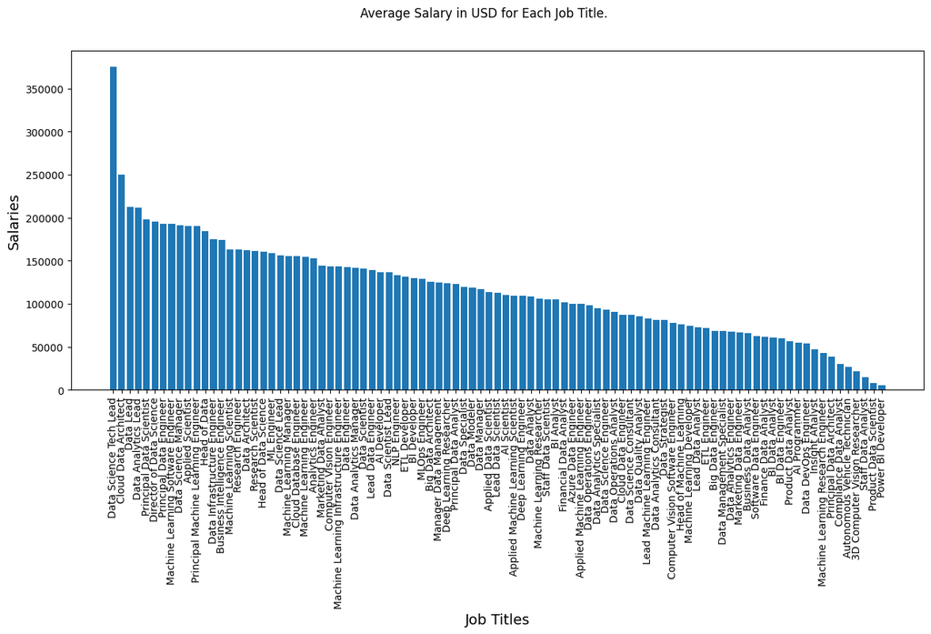

```python
x = jobsal['job_title']
y = jobsal['salary_in_usd']

data = {'Job Titles': x, 'Salaries': y}

jobsal_unsorted = pd.DataFrame(data)

jobsal_sorted = jobsal_unsorted.sort_values(by='Salaries',ascending=False)

plt.figure(figsize=(15,6))

plt.bar(jobsal_sorted['Job Titles'],jobsal_sorted['Salaries'])

plt.xlabel('Job Titles',fontsize=14)
plt.ylabel('Salaries',fontsize=14)
plt.suptitle('Average Salary in USD for Each Job Title.')
plt.xticks(rotation='vertical')
plt.show()
```

#### We can find the job titles with the highest average salary by sorting our dataframe by salary in US dollars from highest to lowest.

```python
jobsal.sort_values(by=['salary_in_usd'],ascending=False)
```

| index | job_title | salary_in_usd |
| --- | --- | --- |
| 47 | Data Science Tech Lead | 375000.000 |
| 20 | Cloud Data Architect | 250000.000 |
| 36 | Data Lead | 212500.000 |
| 29 | Data Analytics Lead | 211254.500 |
| 85 | Principal Data Scientist | 198171.125 |
| ... | ... | ... |
| 10 | Autonomous Vehicle Technician | 26277.500 |
| 1 | 3D Computer Vision Researcher | 21352.250 |
| 92 | Staff Data Analyst | 15000.000 |
| 88 | Product Data Scientist | 8000.000 |
| 81 | Power BI Developer | 5409.000 |

93 rows × 2 columns

#### We found the average salary for each job title in US dollars. The job title with the highest average salary in US dollars is "Data Science Tech Lead" for this data set at $375,000.

## Q2) Find the average salary for each employment type.

#### Someone looking for jobs in the "data" field may want to know what the average salary is for each type of employment.

#### This question follows the same idea as the one we just demonstrated above, so we are going to use the same strategy.

#### First check to see how many unique employment types there are.

```python
df['employment_type'].nunique()
```

```
4
```

#### Create your new dataframe of unique employment types and their average salary in US dollars. We need to get the mean of the salaries in US dollars by grouping by the employment types.

```python
ETsal=pd.DataFrame(df.groupby('employment_type')['salary_in_usd'].mean())
ETsal
```

| employment_type | salary_in_usd |
| --- | --- |
| CT | 113446.900000 |
| FL | 51807.800000 |
| FT | 138314.199570 |
| PT | 39533.705882 |

#### Note that our new dataframe is not structured properly yet, we need employment_type as a column, rather than the index. We have to create a new column based on the index values.

```python
ETsal['employment_type']=ETsal.index
```

#### Now we need to create another column that will become our new index.

```python
ETsal['index']=range(1,ETsal.shape[0]+1)
```

#### Set our new index column as the index.

```python
ETsal=ETsal.set_index('index')
ETsal
```

| index | salary_in_usd | employment_type |
| --- | --- | --- |
| 1 | 113446.900000 | CT |
| 2 | 51807.800000 | FL |
| 3 | 138314.199570 | FT |
| 4 | 39533.705882 | PT |

#### We can reorder the columns into a more intuitive order.

```python
ETsal=ETsal[['employment_type','salary_in_usd']]
ETsal
```

| index | employment_type | salary_in_usd |
| --- | --- | --- |
| 1 | CT | 113446.900000 |
| 2 | FL | 51807.800000 |
| 3 | FT | 138314.199570 |
| 4 | PT | 39533.705882 |

#### We can produce a visual representation of our new dataframe via barchart. Put the unique employment types we found on the x axis, and the average salaries on the y-axis.

```
<function matplotlib.pyplot.show(close=None, block=None)>
```

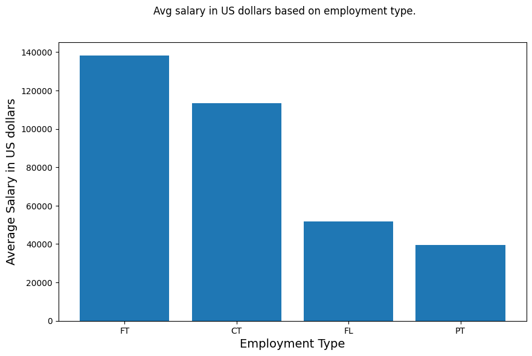

```python
x = ETsal['employment_type']
y = ETsal['salary_in_usd']

data = {'employment_type': x, 'salary_in_usd': y}

df_chart_unsorted = pd.DataFrame(data)

df_chart_sorted = df_chart_unsorted.sort_values(by='salary_in_usd',ascending=False)

plt.figure(figsize=(10,6))

plt.bar(df_chart_sorted['employment_type'], df_chart_sorted['salary_in_usd'])

plt.xlabel('Employment Type',fontsize=14)
plt.ylabel('Average Salary in US dollars',fontsize=14)
plt.suptitle('Avg salary in US dollars based on employment type.')
plt.xticks(rotation='horizontal')
plt.show
```

```python
ETsal.sort_values(by=['salary_in_usd'],ascending=False)
```

| index | employment_type | salary_in_usd |
| --- | --- | --- |
| 3 | FT | 138314.199570 |
| 1 | CT | 113446.900000 |
| 2 | FL | 51807.800000 |
| 4 | PT | 39533.705882 |

#### We found the average salary for each employment type in US dollars. The employment types with the highest average salary in US dollars, ranked highest to lowest is: Full-time, Contract, Freelance, and Part-Time for this dataset.

## Q3) Find the average salary for each experience level.

#### Someone looking for jobs in the "data" field may want to know what the average salary is for each employee experience level.

#### This question follows the same idea as the one we just demonstrated above, so we are going to use the same strategy.

#### First check to see how many unique employment types there are.

```python
df['experience_level'].nunique()
```

```
4
```

#### Create your new dataframe of unique experience_level and their average salary in US dollars. We need to get the mean of the salaries in US dollars by grouping by the experience_level.

```python
ELsal=pd.DataFrame(df.groupby('experience_level')['salary_in_usd'].mean())
ELsal
```

| experience_level | salary_in_usd |
| --- | --- |
| EN | 78546.284375 |
| EX | 194930.929825 |
| MI | 104525.939130 |
| SE | 153051.071542 |

#### Note that our new dataframe is not structured properly yet, we need experience_level as a column, rather than the index. We have to create a new column based on the index values.

```python
ELsal['experience_level']=ELsal.index
```

#### Now we need to create another column that will become our new index.

```python
ELsal['index']=range(1,ELsal.shape[0]+1)
```

#### Set our new index column as the index.

```python
ELsal=ELsal.set_index('index')
ELsal
```

| index | salary_in_usd | experience_level |
| --- | --- | --- |
| 1 | 78546.284375 | EN |
| 2 | 194930.929825 | EX |
| 3 | 104525.939130 | MI |
| 4 | 153051.071542 | SE |

#### We can reorder the columns into a more intuitive order.

```python
ELsal=ELsal[['experience_level','salary_in_usd']]
ELsal
```

| index | experience_level | salary_in_usd |
| --- | --- | --- |
| 1 | EN | 78546.284375 |
| 2 | EX | 194930.929825 |
| 3 | MI | 104525.939130 |
| 4 | SE | 153051.071542 |

#### We can produce a visual representation of our new dataframe via barchart. Put the unique experience levels we found on the x axis, and the average salaries on the y-axis.

```
<function matplotlib.pyplot.show(close=None, block=None)>
```

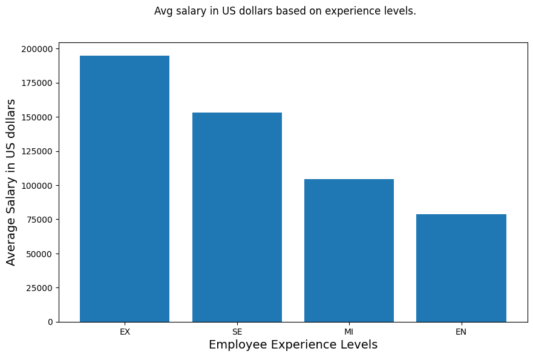

```python
x = ELsal['experience_level']
y = ELsal['salary_in_usd']

data = {'experience_level': x, 'salary_in_usd': y}

df_chart_unsorted = pd.DataFrame(data)

df_chart_sorted = df_chart_unsorted.sort_values(by='salary_in_usd',ascending=False)

plt.figure(figsize=(10,6))

plt.bar(df_chart_sorted['experience_level'], df_chart_sorted['salary_in_usd'])

plt.xlabel('Employee Experience Levels',fontsize=14)
plt.ylabel('Average Salary in US dollars',fontsize=14)
plt.suptitle('Avg salary in US dollars based on experience levels.')
plt.xticks(rotation='horizontal')
plt.show
```

#### We can find the employee experience levels with the highest average salary by sorting our dataframe by salary in US dollars from highest to lowest.

```python
ELsal.sort_values(by=['salary_in_usd'],ascending=False)
```

| index | experience_level | salary_in_usd |
| --- | --- | --- |
| 2 | EX | 194930.929825 |
| 4 | SE | 153051.071542 |
| 3 | MI | 104525.939130 |
| 1 | EN | 78546.284375 |

#### We found the average salary for each employee experince level in US dollars. The experince levels ranked from highest to lowest in terms of average salary in US dollars is: Executive, Senior, Mid-level, and Entry-level for this dataset.

## Q4) Find the average salary of the different company sizes in US dollars.

#### Someone looking for jobs in the "data" field may want to know what the average salary is for the different company sizes.

#### This question follows the same idea as the one we just demonstrated above, so we are going to use the same strategy.

#### First check to see how many unique company sizes there are.

```python
df['company_size'].nunique()
```

```
3
```

#### Create your new dataframe of unique company_sizes and their average salary in US dollars. We need to get the mean of the salaries in US dollars by grouping by the company_size.

```python
sizesal=pd.DataFrame(df.groupby('company_size')['salary_in_usd'].mean())
sizesal
```

| company_size | salary_in_usd |
| --- | --- |
| L | 118300.982379 |
| M | 143130.548367 |
| S | 78226.682432 |

#### Note that our new dataframe is not structured properly yet, we need company_size as a column, rather than the index. We have to create a new column based on the index values.

```python
sizesal['company_size']=sizesal.index
```

#### Now we need to create another column that will become our new index.

```python
sizesal['index']=range(1,sizesal.shape[0]+1)
```

#### Set our new index column as the index.

```python
sizesal=sizesal.set_index('index')
sizesal
```

| index | salary_in_usd | company_size |
| --- | --- | --- |
| 1 | 118300.982379 | L |
| 2 | 143130.548367 | M |
| 3 | 78226.682432 | S |

#### We can reorder the columns into a more intuitive order.

```python
sizesal=sizesal[['company_size','salary_in_usd']]
sizesal
```

| index | company_size | salary_in_usd |
| --- | --- | --- |
| 1 | L | 118300.982379 |
| 2 | M | 143130.548367 |
| 3 | S | 78226.682432 |

#### We can produce a visual representation of our new dataframe via barchart. Put the unique company sizes we found on the x axis, and the average salaries on the y-axis.

```
<function matplotlib.pyplot.show(close=None, block=None)>
```

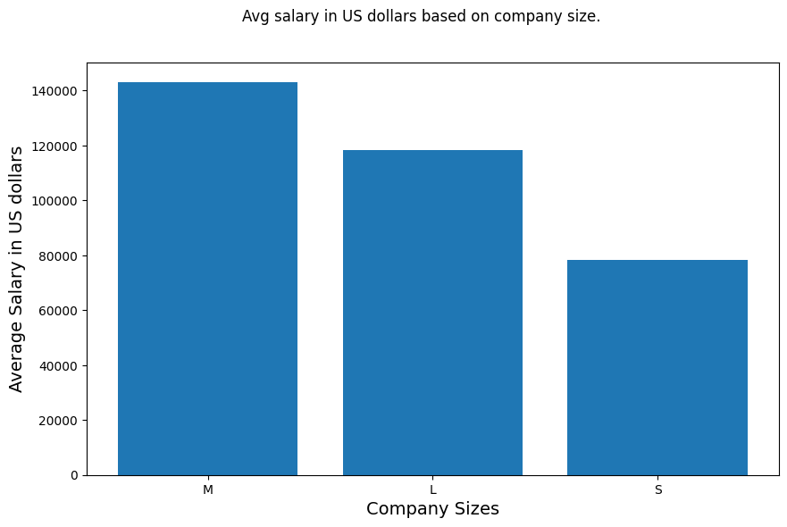

```python
x = sizesal['company_size']
y = sizesal['salary_in_usd']

data = {'company_size': x, 'salary_in_usd': y}

df_chart_unsorted = pd.DataFrame(data)

df_chart_sorted = df_chart_unsorted.sort_values(by='salary_in_usd',ascending=False)

plt.figure(figsize=(10,6))

plt.bar(df_chart_sorted['company_size'], df_chart_sorted['salary_in_usd'])

plt.xlabel('Company Sizes',fontsize=14)
plt.ylabel('Average Salary in US dollars',fontsize=14)
plt.suptitle('Avg salary in US dollars based on company size.')
plt.xticks(rotation='horizontal')
plt.show
```

#### We can find the employee company sizes with the highest average salary by sorting our dataframe by salary in US dollars from highest to lowest.

```python
sizesal.sort_values(by=['salary_in_usd'],ascending=False)
```

| index | company_size | salary_in_usd |
| --- | --- | --- |
| 2 | M | 143130.548367 |
| 1 | L | 118300.982379 |
| 3 | S | 78226.682432 |

#### We found the average salary for each company size in US dollars. The company sizes ranked from highest to lowest in terms of average salary in US dollars is: Middle, Large, and Small for this data set.

## Q5) Find the number of people working in each job title.

#### Someone looking for jobs in the "data" field may want to know how many people are woking under each job title.

#### This question requires a slightly different strategy as we are looking for the count of records, rather than the average of a column.

#### Create your new dataframe of the count of people working under each job title. We need to get the count of the people by grouping by job title.

```python
numemp=pd.DataFrame(df.groupby('job_title')['salary_in_usd'].count())
numemp
```

| job_title | salary_in_usd |
| --- | --- |
| 3D Computer Vision Researcher | 4 |
| AI Developer | 11 |
| AI Programmer | 2 |
| AI Scientist | 16 |
| Analytics Engineer | 103 |
| ... | ... |
| Research Engineer | 37 |
| Research Scientist | 82 |
| Software Data Engineer | 2 |
| Staff Data Analyst | 1 |
| Staff Data Scientist | 1 |

93 rows × 1 columns

#### Rename our column that has a placeholder name to count.

```python
numemp.rename(columns={'salary_in_usd': 'count'}, inplace=True)
numemp
```

| job_title | count |
| --- | --- |
| 3D Computer Vision Researcher | 4 |
| AI Developer | 11 |
| AI Programmer | 2 |
| AI Scientist | 16 |
| Analytics Engineer | 103 |
| ... | ... |
| Research Engineer | 37 |
| Research Scientist | 82 |
| Software Data Engineer | 2 |
| Staff Data Analyst | 1 |
| Staff Data Scientist | 1 |

93 rows × 1 columns

#### Note that our new dataframe is not structured properly yet, we need job_title as a column, rather than the index. We have to create a new column based on the index values.

```python
numemp['job_title']=numemp.index
```

#### Now we need to create another column that will become our new index.

```python
numemp['index']=range(1,numemp.shape[0]+1)
```

#### Set our new index column as the index.

```python
numemp=numemp.set_index('index')
numemp
```

| index | count | job_title |
| --- | --- | --- |
| 1 | 4 | 3D Computer Vision Researcher |
| 2 | 11 | AI Developer |
| 3 | 2 | AI Programmer |
| 4 | 16 | AI Scientist |
| 5 | 103 | Analytics Engineer |
| ... | ... | ... |
| 89 | 37 | Research Engineer |
| 90 | 82 | Research Scientist |
| 91 | 2 | Software Data Engineer |
| 92 | 1 | Staff Data Analyst |
| 93 | 1 | Staff Data Scientist |

93 rows × 2 columns

#### We can reorder the columns into a more intuitive order.

```python
numemp=numemp[['job_title','count']]
numemp
```

| index | job_title | count |
| --- | --- | --- |
| 1 | 3D Computer Vision Researcher | 4 |
| 2 | AI Developer | 11 |
| 3 | AI Programmer | 2 |
| 4 | AI Scientist | 16 |
| 5 | Analytics Engineer | 103 |
| ... | ... | ... |
| 89 | Research Engineer | 37 |
| 90 | Research Scientist | 82 |
| 91 | Software Data Engineer | 2 |
| 92 | Staff Data Analyst | 1 |
| 93 | Staff Data Scientist | 1 |

93 rows × 2 columns

#### We can produce a visual representation of our new dataframe via barchart. Put the unique job titles we found on the x axis, and the count on the y-axis.

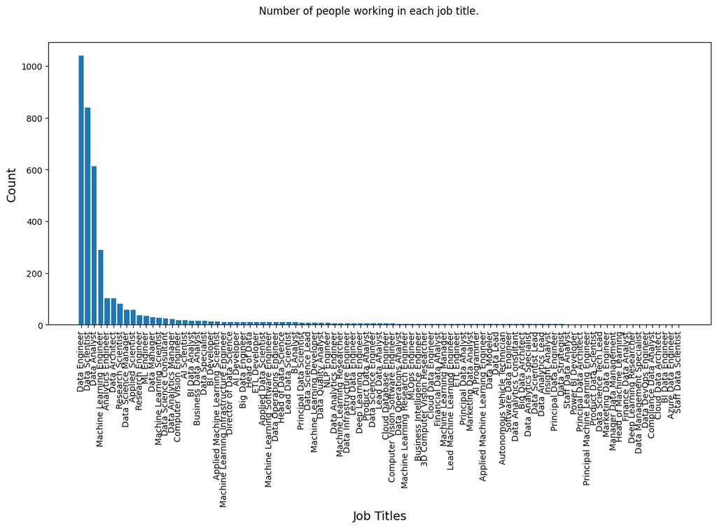

```python
x = numemp['job_title']
y = numemp['count']

data = {'job_title': x, 'Count': y}

df_chart_unsorted = pd.DataFrame(data)

df_chart_sorted = df_chart_unsorted.sort_values(by='Count',ascending=False)

plt.figure(figsize=(14,6))

plt.bar(df_chart_sorted['job_title'], df_chart_sorted['Count'])

plt.xlabel('Job Titles',fontsize=14)
plt.ylabel('Count',fontsize=14)
plt.suptitle('Number of people working in each job title.')
plt.xticks(rotation='vertical')
plt.show()
```

#### We can find the job titles with the highest count by sorting our dataframe by count from highest to lowest.

```python
numemp.sort_values(by=['count'],ascending=False)
```

| index | job_title | count |
| --- | --- | --- |
| 34 | Data Engineer | 1040 |
| 48 | Data Scientist | 840 |
| 26 | Data Analyst | 612 |
| 70 | Machine Learning Engineer | 289 |
| 5 | Analytics Engineer | 103 |
| ... | ... | ... |
| 23 | Compliance Data Analyst | 1 |
| 20 | Cloud Data Architect | 1 |
| 14 | BI Data Engineer | 1 |
| 11 | Azure Data Engineer | 1 |
| 93 | Staff Data Scientist | 1 |

93 rows × 2 columns

#### We found the number of people working under each job title. The job title with the most poeple working under it is "Data Engineer" with 1040 people for this dataset.

## Q6) Find the number of people working in each employment_type for each company size.

#### Someone looking for jobs in the "data" field may want to know how many people are working as different employment types for different company sizes.

#### Like question five, this question requires a slightly different strategy as we are looking for the count of records, rather than the average of a column. Also this question requires a more specific grouping because of the two categorical columns (employment_type and company_size).

#### Create your new dataframe of the count of people working under each employment type and company size. We need to get the count of the people by grouping by both company size and employment type.

```python
etcsize=pd.DataFrame(df.groupby(['company_size','employment_type'])['salary'].count())
etcsize
```

| company_size | employment_type | salary |
| --- | --- | --- |
| L | CT | 2 |
|  | FL | 1 |
|  | FT | 445 |
|  | PT | 6 |
| M | CT | 4 |
|  | FL | 5 |
|  | FT | 3139 |
|  | PT | 5 |
| S | CT | 4 |
|  | FL | 4 |
|  | FT | 134 |
|  | PT | 6 |

#### Rename our column that has a placeholder name to count.

```python
etcsize.rename(columns={'salary': 'count'}, inplace=True)
etcsize
```

| company_size | employment_type | count |
| --- | --- | --- |
| L | CT | 2 |
|  | FL | 1 |
|  | FT | 445 |
|  | PT | 6 |
| M | CT | 4 |
|  | FL | 5 |
|  | FT | 3139 |
|  | PT | 5 |
| S | CT | 4 |
|  | FL | 4 |
|  | FT | 134 |
|  | PT | 6 |

#### Note that our new dataframe is not structured properly yet, we need company_size and employment type as columns, rather than the index. We have to create a new column based on the index values.

```python
etcsize['Size_and_type']=etcsize.index
```

#### Now we need to create another column that will become our new index.

```python
etcsize['index']=range(1,etcsize.shape[0]+1)
```

#### Set our new index column as the index.

```python
etcsize=etcsize.set_index('index')
etcsize
```

| index | count | Size_and_type |
| --- | --- | --- |
| 1 | 2 | (L, CT) |
| 2 | 1 | (L, FL) |
| 3 | 445 | (L, FT) |
| 4 | 6 | (L, PT) |
| 5 | 4 | (M, CT) |
| 6 | 5 | (M, FL) |
| 7 | 3139 | (M, FT) |
| 8 | 5 | (M, PT) |
| 9 | 4 | (S, CT) |
| 10 | 4 | (S, FL) |
| 11 | 134 | (S, FT) |
| 12 | 6 | (S, PT) |

#### We can reorder the columns into a more intuitive order.

```python
etcsize=etcsize[['Size_and_type','count']]
etcsize
```

| index | Size_and_type | count |
| --- | --- | --- |
| 1 | (L, CT) | 2 |
| 2 | (L, FL) | 1 |
| 3 | (L, FT) | 445 |
| 4 | (L, PT) | 6 |
| 5 | (M, CT) | 4 |
| 6 | (M, FL) | 5 |
| 7 | (M, FT) | 3139 |
| 8 | (M, PT) | 5 |
| 9 | (S, CT) | 4 |
| 10 | (S, FL) | 4 |
| 11 | (S, FT) | 134 |
| 12 | (S, PT) | 6 |

#### We can produce a visual representation of our new dataframe via barchart. Put the unique company sizes and employment types we found on the x axis, and the count on the y-axis.

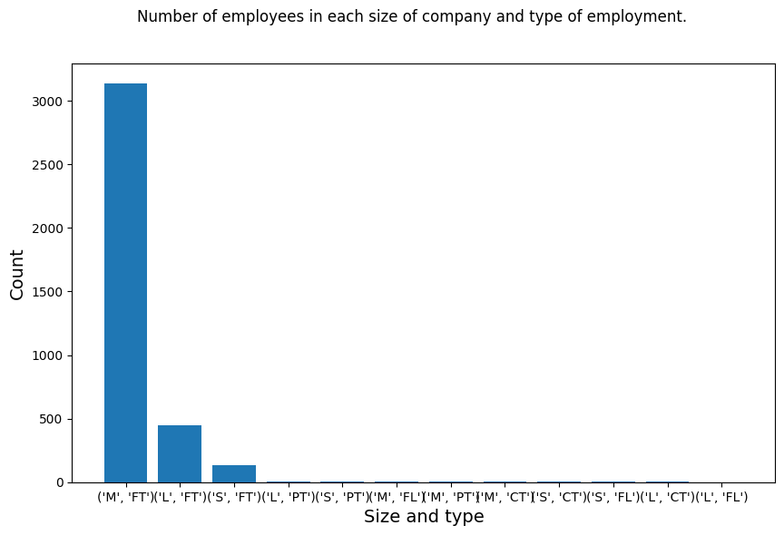

```python
x = etcsize['Size_and_type']
y = etcsize['count']

data = {'Size and type': x, 'Count': y}

df_chart_unsorted = pd.DataFrame(data)

df_chart_sorted = df_chart_unsorted.sort_values(by='Count',ascending=False)

plt.figure(figsize=(10,6))

plt.bar(df_chart_sorted['Size and type'].astype('string'), df_chart_sorted['Count'])

plt.xlabel('Size and type',fontsize=14)
plt.ylabel('Count',fontsize=14)
plt.suptitle('Number of employees in each size of company and type of employment.')
plt.xticks(rotation='horizontal')
plt.show()
```

#### We can find the company size and employment type with the highest count by sorting our dataframe by count from highest to lowest.

```python
etcsize.sort_values(by=['count'],ascending=False)
```

| index | Size_and_type | count |
| --- | --- | --- |
| 7 | (M, FT) | 3139 |
| 3 | (L, FT) | 445 |
| 11 | (S, FT) | 134 |
| 4 | (L, PT) | 6 |
| 12 | (S, PT) | 6 |
| 6 | (M, FL) | 5 |
| 8 | (M, PT) | 5 |
| 5 | (M, CT) | 4 |
| 9 | (S, CT) | 4 |
| 10 | (S, FL) | 4 |
| 1 | (L, CT) | 2 |
| 2 | (L, FL) | 1 |

#### We found the number of people working under each company size and employment type. The company sizes are small for S, medium for M, and large for L. The employment types are Full-Time for FT, Part-Time for PT, Contract for CT, and Freelance for FL. The company size and employment type with the most poeple working under it is medium sized companies with full-time working employees at 3139 people for this dataset.

## Q7) Find average salary for specific job of interest in 2023.

#### Someone looking for jobs in the "data" field may want to know specifics about 2023 Data Scientists who are working full time remotely from their residence in the US.

#### This question is very different from what we previously worked on. Here we will filtering in order to get the records of very specific jobs. We will use multiple conditions when creating a new dataframe consisting only of the records we want.

#### Create your new dataframe of the records of 2023 Data Scientists who are working full time remotely from their residence in the US.

```python
exjobs23=pd.DataFrame(df[(df['job_title']=='Data Scientist') & (df['employee_residence']=='US') & (df['employment_type']=='FT') & (df['work_year']==2023) & (df['remote_ratio']==100)])
exjobs23
```

|  | work_year | experience_level | employment_type | job_title | salary | salary_currency | salary_in_usd | employee_residence | remote_ratio | company_location | company_size |
| --- | --- | --- | --- | --- | --- | --- | --- | --- | --- | --- | --- |
| 46 | 2023 | SE | FT | Data Scientist | 212750 | USD | 212750 | US | 100 | US | M |
| 47 | 2023 | SE | FT | Data Scientist | 185000 | USD | 185000 | US | 100 | US | M |
| 48 | 2023 | SE | FT | Data Scientist | 262000 | USD | 262000 | US | 100 | US | M |
| 49 | 2023 | SE | FT | Data Scientist | 245000 | USD | 245000 | US | 100 | US | M |
| 50 | 2023 | SE | FT | Data Scientist | 275300 | USD | 275300 | US | 100 | US | M |
| ... | ... | ... | ... | ... | ... | ... | ... | ... | ... | ... | ... |
| 1682 | 2023 | SE | FT | Data Scientist | 84000 | USD | 84000 | US | 100 | US | M |
| 1712 | 2023 | SE | FT | Data Scientist | 135000 | USD | 135000 | US | 100 | US | M |
| 1713 | 2023 | SE | FT | Data Scientist | 115000 | USD | 115000 | US | 100 | US | M |
| 1716 | 2023 | SE | FT | Data Scientist | 170000 | USD | 170000 | US | 100 | US | M |
| 1717 | 2023 | SE | FT | Data Scientist | 140000 | USD | 140000 | US | 100 | US | M |

124 rows × 11 columns

#### Find the average of the salaries in Us dollars for our data set and save it in a variable for later...we will be using it to look at trends.

```python
sal23=exjobs23['salary_in_usd'].mean()
sal23
```

```
171274.57258064515
```

#### We found that the average salary for the specific job of interest in 2023 was approximately $171,274 for this dataset.

## Q8) Find average salary for specific job of interest in 2022.

#### Someone looking for jobs in the "data" field may want to know specifics about 2022 Data Scientists who are working full time remotely from their residence in the US.

#### Here we are doing the same exact process as the previous question, but for a different work year.

#### Create your new dataframe of the records of 2022 Data Scientists who are working full time remotely from their residence in the US.

```python
exjobs22=pd.DataFrame(df[(df['job_title']=='Data Scientist') & (df['employee_residence']=='US') & (df['employment_type']=='FT') & (df['work_year']==2022) & (df['remote_ratio']==100)])
exjobs22
```

|  | work_year | experience_level | employment_type | job_title | salary | salary_currency | salary_in_usd | employee_residence | remote_ratio | company_location | company_size |
| --- | --- | --- | --- | --- | --- | --- | --- | --- | --- | --- | --- |
| 1069 | 2022 | EN | FT | Data Scientist | 168000 | USD | 168000 | US | 100 | US | M |
| 1347 | 2022 | EN | FT | Data Scientist | 180000 | USD | 180000 | US | 100 | US | M |
| 1443 | 2022 | MI | FT | Data Scientist | 155000 | USD | 155000 | US | 100 | US | L |
| 1611 | 2022 | MI | FT | Data Scientist | 110000 | USD | 110000 | US | 100 | US | L |
| 1746 | 2022 | EN | FT | Data Scientist | 100000 | USD | 100000 | US | 100 | US | M |
| ... | ... | ... | ... | ... | ... | ... | ... | ... | ... | ... | ... |
| 3414 | 2022 | SE | FT | Data Scientist | 185100 | USD | 185100 | US | 100 | US | M |
| 3415 | 2022 | SE | FT | Data Scientist | 104890 | USD | 104890 | US | 100 | US | M |
| 3439 | 2022 | MI | FT | Data Scientist | 78000 | USD | 78000 | US | 100 | US | M |
| 3449 | 2022 | SE | FT | Data Scientist | 165000 | USD | 165000 | US | 100 | US | M |
| 3462 | 2022 | MI | FT | Data Scientist | 135000 | USD | 135000 | US | 100 | US | L |

189 rows × 11 columns

#### Find the average of the salaries in US dollars for our data set and save it in a variable for later...we will be using it to look at trends.

```python
sal22=exjobs22['salary_in_usd'].mean()
sal22
```

```
153404.30687830687
```

#### We found that the average salary for the specific job of interest in 2022 was approximately $153,404 for this dataset.

## Q9) Find average salary for specific job of interest in 2021.

#### Someone looking for jobs in the "data" field may want to know specifics about 2021 Data Scientists who are working full time remotely from their residence in the US.

#### Here we are doing the same exact process as the previous question, but for a different work year.

#### Create your new dataframe of the records of 2021 Data Scientists who are working full time remotely from their residence in the US.

```python
exjobs21=pd.DataFrame(df[(df['job_title']=='Data Scientist') & (df['employee_residence']=='US') & (df['employment_type']=='FT') & (df['work_year']==2021) & (df['remote_ratio']==100)])
exjobs21
```

|  | work_year | experience_level | employment_type | job_title | salary | salary_currency | salary_in_usd | employee_residence | remote_ratio | company_location | company_size |
| --- | --- | --- | --- | --- | --- | --- | --- | --- | --- | --- | --- |
| 3467 | 2021 | EN | FT | Data Scientist | 80000 | USD | 80000 | US | 100 | US | M |
| 3487 | 2021 | MI | FT | Data Scientist | 82500 | USD | 82500 | US | 100 | US | S |
| 3529 | 2021 | MI | FT | Data Scientist | 150000 | USD | 150000 | US | 100 | US | M |
| 3591 | 2021 | EN | FT | Data Scientist | 90000 | USD | 90000 | US | 100 | US | S |
| 3602 | 2021 | SE | FT | Data Scientist | 165000 | USD | 165000 | US | 100 | US | L |
| 3627 | 2021 | EN | FT | Data Scientist | 100000 | USD | 100000 | US | 100 | US | M |
| 3700 | 2021 | MI | FT | Data Scientist | 160000 | USD | 160000 | US | 100 | US | L |

#### Find the average of the salaries in Us dollars for our data set and save it in a variable for later...we will be using it to look at trends.

```python
sal21=exjobs21['salary_in_usd'].mean()
sal21
```

```
118214.28571428571
```

#### We found that the average salary for the specific job of interest in 2021 was approximately $118,214 for this dataset.

## Trend from questions 7-9

### The last 3 questions we asked and got our answers to show an interesting trend. The trend is that each year, the average salary for the specific job of interest is increasing:

```python
print('2023 Avg Sal:'+str(sal23))
print('2022 Avg Sal:'+str(sal22))
print('2021 Avg Sal:'+str(sal21))
```

```
2023 Avg Sal:171274.57258064515
2022 Avg Sal:153404.30687830687
2021 Avg Sal:118214.28571428571
```

#### We can produce a visual representation of this trend via barchart. Put the different working years on the x axis, and the average salaries on the y-axis.

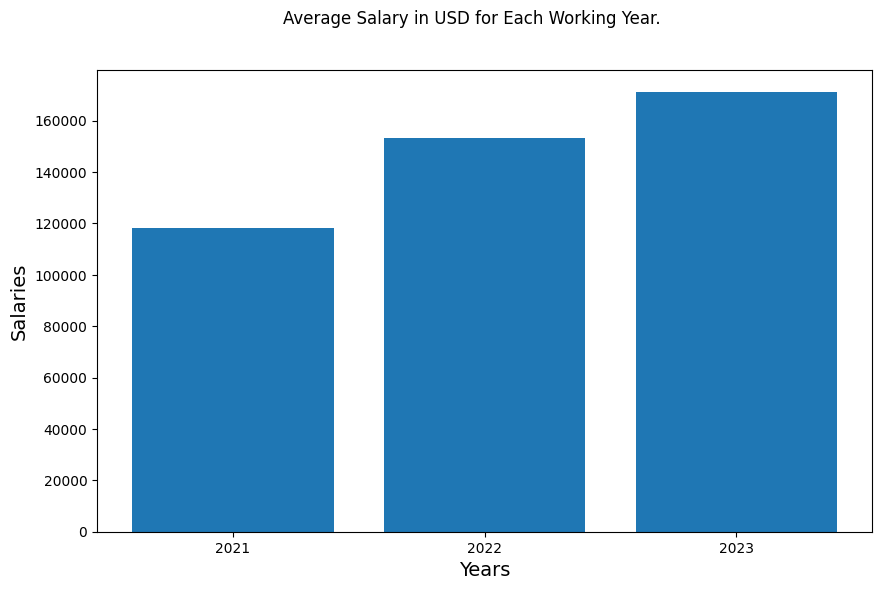

```python
x = ['2021','2022','2023']
y = [sal21,sal22,sal23]

data = {'Years': x, 'Salaries': y}

df_chart = pd.DataFrame(data)

plt.figure(figsize=(10,6))

plt.bar(df_chart['Years'], df_chart['Salaries'])

plt.xlabel('Years',fontsize=14)
plt.ylabel('Salaries',fontsize=14)
plt.suptitle('Average Salary in USD for Each Working Year.')
plt.xticks(rotation='horizontal')
plt.show()
```